# Homework 1

Jimmy Hickey

**1. Assume $Y_{1}, \dots , Y_{n} \mid \theta \sim \text{Uniform}(0,\theta)$ independent over $i$.**

**(a) Identify a conjugate family of prior distributions for $\theta$ and derive the posterior**

Our joint likelihood is

$$\begin{align*}
f(y_{1} , \dots , y_{n} \mid \theta) & = \prod_{i=1}^{n} \frac{ 1 }{ \theta-0} \mathbb{I}(0 \leq y_{i} \leq \theta) \\
& = \frac{ 1}{ \theta^{n} } \mathbb{I}(0 \leq y_{(1)}) \mathbb{I}(y_{(n)} \leq \theta).
\end{align*}$$

Then we take the conjugate prior $\theta \sim \text{Pareto}(\theta_{m}, \alpha)$ to get the posterior

$$\begin{align*}
p(\theta \mid Y_{1} , \dots , Y_{n}) & = f(y_{1} , \dots , y_{n} \mid \theta) \pi(\theta) \\
& = \frac{ 1}{ \theta^{n} } \mathbb{I}(0 \leq y_{(1)}) \mathbb{I}(y_{(n)} \leq \theta) \frac{\alpha \theta_{m}^{\alpha} }{ \theta^{\alpha+1} } \mathbb{I}(\theta_{m} \leq \theta) \\
& \propto \frac{1 }{ \theta^{(n+\alpha) + 1} } \mathbb{I}(y_{(n)} \leq \theta) \mathbb{I}(\theta_{m} \leq \theta) \\
& = \frac{1 }{ \theta^{(n+\alpha) + 1} } \mathbb{I}(\max (y_{(n)}, \theta_{m}) \leq \theta).
\end{align*}$$

This is the kernel of a Pareto distribution. Thus, $\theta \mid Y_{1}, \dots Y_{n} \sim \text{Pareto}(\max(y_{(n)}, \theta_{m}), n + \alpha)$.

**(b) Now assume you observe $n=50$ samples as below**

```
> set.seed(919)
> Y <- runif(50,0,10)
> range(Y)
[1] 0.05161189 9.75337425
```

**Use an uninformative prior and summarize the posterior in a table and plot**

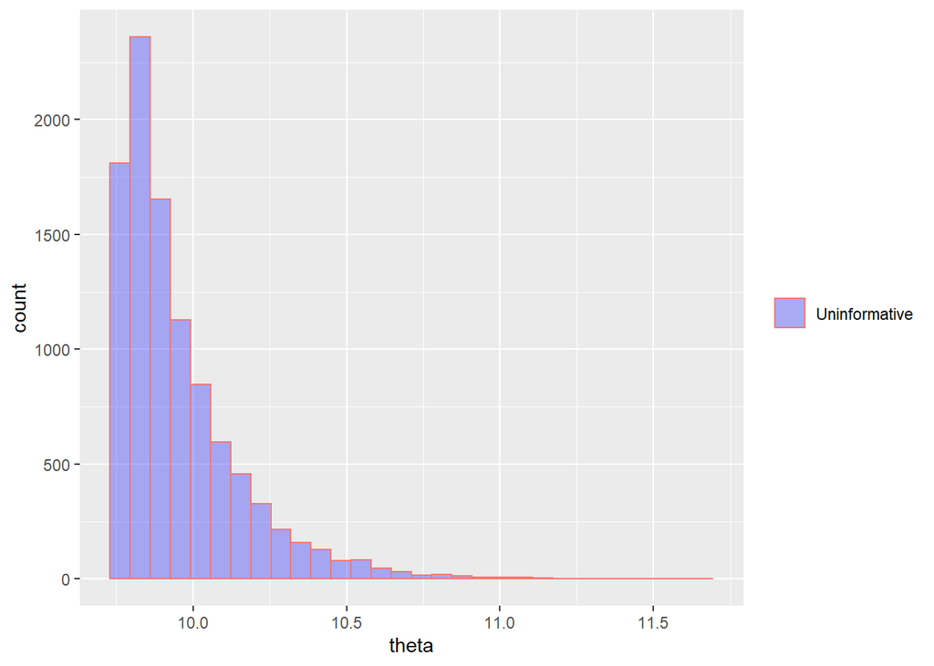

```r
# import EnvStats for rpareto
library(EnvStats)
library(ggplot2)
set.seed(919)
n = 50
true_theta = 10
Y <- runif(n,0,true_theta)
S = 10000
theta_m = alpha = 0.1
theta_uninformative = rpareto(S, max(max(Y), theta_m), n + alpha)
df = data.frame(theta_uninformative)
ggplot(df) +
  geom_histogram(aes(x=theta_uninformative, color="Uninformative"), alpha=0.3, fill="blue") +
  labs(x = "theta") +
  theme(legend.title=element_blank())
```

```r
theta_mean = mean(theta_uninformative)
theta_sd = sd(theta_uninformative)
theta_lower = theta_mean - qnorm(0.975) * theta_sd
theta_upper = theta_mean + qnorm(0.975) * theta_sd
```

|  | Posterior Mean | Posterior SD | 95% credible set |
| --- | --- | --- | --- |
| uninformative $\theta$ | 9.95 | 0.20 | (9.56, 10.35) |

**(c) Is the posterior sensitive to the prior?**

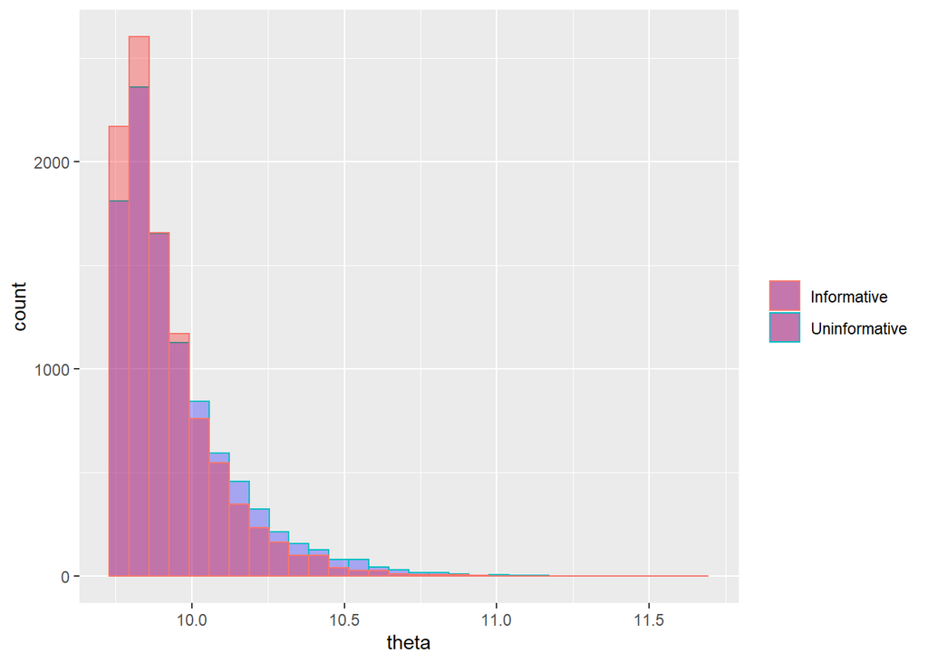

```r
# import EnvStats for rpareto
set.seed(919)
n = 50
true_theta = 10
Y <- runif(n,0,true_theta)
S = 10000
theta_m = 9
alpha = 10
theta_informative = rpareto(S, max(max(Y), theta_m), n + alpha)
df$theta_informative = theta_informative

ggplot(df) +
  geom_histogram(aes(x=theta_uninformative, color="Uninformative"), alpha=0.3, fill="blue") +
  geom_histogram(aes(x=theta_informative, color="Informative"), alpha=0.3, fill="red") +
  labs(x = "theta") +
  theme(legend.title=element_blank())
```

```r
theta_mean = mean(theta_informative)
theta_sd = sd(theta_informative)
theta_lower = theta_mean - qnorm(0.975) * theta_sd
theta_upper = theta_mean + qnorm(0.975) * theta_sd
```

|  | Posterior Mean | Posterior SD | 95% credible set |
| --- | --- | --- | --- |
| uninformative prior $\theta$ | 9.95 | 0.20 | (9.56, 10.35) |
| informative prior $\theta$ | 9.92 | 0.17 | (9.59, 10.25) |

Switching to an informative prior centered on the true value of $\theta$ slightly reduced the posterior standard deviation and in turn the length of the credible set.

**(d) What is the posterior predictive probability that $Y_{n+1}$ will be a new record, i.e.,**

$$\text{Prob}(Y_{n+1} > \max\{ Y_{1}, \dots Y_{n} \} \mid Y_{1}, \dots Y_{n})$$

We first need to PDF of the posterior predictive distribution

$$\begin{align*}
f_{Y_{n+1} \mid Y_{1}, \dots Y_{n}} & = \int_{0}^{\infty} f(Y_{n+1} \mid \theta) p(\theta \mid y_{1}, \dots , y_{n}) \ d\theta \\
& = \int_{0}^{\infty} \frac{ 1}{\theta - 0 } \frac{ (\alpha+n) \max(Y_{(n)}, \theta_{m})^{\alpha+n} }{ \theta^{(\alpha+n)+1}} \mathbb{I}(\max(Y_{(n)}) \leq \theta) \ d\theta \\
& = \frac{\alpha + n }{\alpha+ n +1 } \frac{1 }{ \max(Y_{(n)}, \theta_{m}) } \int_{0}^{\infty} \frac{(\alpha+n+1)\max(Y_{(n)} ,\theta_{m})^{\alpha+n+1} }{ \theta^{(\alpha+n+1)+1}} \mathbb{I}(\max(Y_{(n)}, \theta_{m}) \leq \theta) \ d\theta \\
& = \frac{\alpha + n }{\alpha+ n +1 } \frac{1 }{ \max(Y_{(n)}, \theta_{m}) } \cdot 1,
\end{align*}$$

where the last step comes from integrating a Pareto PDF over its support. Now we can calculate the CDF,

$$\begin{align*}
F_{Y_{n+1}\mid Y_{1} , \dots,Y_{n}}(y) & = \int_{0}^{y} \frac{\alpha + n }{\alpha+ n +1 } \frac{1 }{ \max(Y_{(n)}, \theta_{m}) } \ dy_{n+1} \\
& = \frac{\alpha + n }{\alpha+ n +1 } \frac{y }{ \max(Y_{(n)}, \theta_{m}) }.
\end{align*}$$

Thus,

$$\begin{align*}
\text{Prob}(Y_{n+1} > Y_{(n)} \mid Y_{1}, \dots Y_{n}) & = 1-F_{Y_{n+1}\mid Y_{1} , \dots,Y_{n}}(Y_{(n)}) \\
& = 1 - \frac{\alpha +n }{ \alpha + n + 1 } \frac{ Y_{(n)} }{ \max(Y_{(n)}, \theta_{m})}.
\end{align*}$$

**(e) Why is (d) not exactly $1/(n+1)$, or is it?**

This is not exactly $1/(n+1)$ because of the influence of the $\theta$ prior. If we set the prior parameters $\alpha = \theta_{m} = 0$ then we get,

$$\begin{align*}
\text{Prob}(Y_{n+1} > Y_{(n)} \mid Y_{1}, \dots Y_{n}) & 1 - \frac{\alpha +n }{ \alpha + n + 1 } \frac{ Y_{(n)} }{ \max(Y_{(n)}, \theta_{m})} \\
& = 1 - \frac{0 +n }{ 0 + n + 1 } \frac{ Y_{(n)} }{ \max(Y_{(n)}, 0)} \\
& = 1 - \frac{ n}{n+1 } \\
& =\frac{ 1 }{ n+1}.
\end{align*}$$

**2. Download the daily weather data from RDU Airport**

**(a) Plot the sample correlation between daily minimum (TMIN) and maximum (TMAX) temperature by month.**

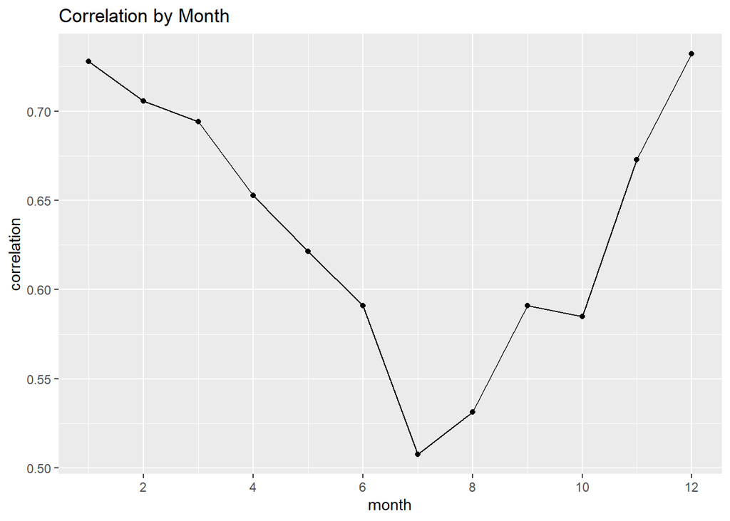

```r
library(scales)
library(dplyr)
library(ggplot2)
file <- "https://www4.stat.ncsu.edu/~bjreich/ST740/RDU.csv"
dat <- read.csv(url(file))
TMAX <- dat[,2]/10
TMIN <- dat[,3]/10
MONTH <- dat[,4]
DATE = dat[,1]
weather = data.frame(date = DATE,temp_max = TMAX,temp_min = TMIN,month = MONTH)

weather = weather %>% group_by(month) %>% mutate(correlation = cor(temp_max,temp_min))

ggplot(weather, aes(x=month, y=correlation)) + geom_line() + geom_point() + ggtitle("Correlation by Month")+ scale_x_continuous(breaks= pretty_breaks())
```

**(b) Let $Y = (T_{MIN}, T_{MAX})$ be a bivariate response and fit the model $Y \mid \Sigma \sim \text{Normal}(\overline{ Y }, \Sigma)$ where $\overline{ Y }$ is the sample mean of $Y$ (Say it is fixed and known) and $\Sigma$ is the unknown $2 \times 2$ covariance matrix. Specify a conjugate family of prior distribution for $\Sigma$ and derive the corresponding posterior.**

**Hint: Recall that for vector $a$ and square matrices $B$ and $C$ that $a^{\top}Ba = \text{tr}( a^{T} B a ) = \text{tr}( Baa^{\top} )$ and $\text{tr}( a^{\top}B ) + \text{tr}(a^{\top} C ) = \text{tr}(a^{\top} (B+C) )$.**

The data likelihood is

$$\begin{align*}
f(Y \mid \Sigma) & \propto \mid \Sigma \mid^{-n/2} \exp \Big\{ -\frac{ 1 }{ 2}(Y - \overline{ Y })^{\top} \Sigma^{-1} (Y - \overline{ Y })\Big\}.
\end{align*}$$

Then take a $\Sigma \sim \text{InverseWishart}(\Psi, \nu)$ prior. The posterior is

$$\begin{align*}
p(\Sigma \mid Y) & \propto \mid \Sigma \mid^{-n/2} \exp \Big\{ -\frac{ 1 }{ 2}(Y - \overline{ Y })^{\top} \Sigma^{-1} (Y - \overline{ Y })\Big\}
\mid \Sigma \mid ^{-(\nu + p + 1) / 2}
\exp \Big\{ -\frac{ 1 }{ 2 } \text{tr}(\Psi \Sigma^{-1} ) \Big\} \\
& = \exp \Big( -\frac{ 1 }{ 2}\Big[ \text{tr}\Big\{(Y - \overline{ Y })^{\top} \Sigma^{-1} (Y - \overline{ Y })\Big\} + \text{tr}(\Psi \Sigma^{-1}) \Big]\Big)
\mid \Sigma \mid ^{-(\nu + n + p + 1) / 2} \\
& = \exp \Big( -\frac{ 1 }{ 2}\Big[ \text{tr}\Big\{ \Sigma^{-1} (Y - \overline{ Y })(Y - \overline{ Y })^{\top}\Big\} + \text{tr}(\Sigma^{-1} \Psi\Big) \Big]\Big)
\mid \Sigma \mid ^{-(\nu + n + p + 1) / 2} \\
& = \exp \Big\{ -\frac{ 1 }{ 2}\Big( \text{tr}\Big[ \Sigma^{-1} \Big\{(Y - \overline{ Y })(Y - \overline{ Y })^{\top}+ \Psi \Big\} \Big] \Big)\Big\}
\mid \Sigma \mid ^{-(\nu + n + p + 1) / 2} \\
& = \exp \Big\{ -\frac{ 1 }{ 2}\Big( \text{tr}\Big[ \Big\{ \Psi + (Y - \overline{ Y })(Y - \overline{ Y })^{\top} \Big\} \Sigma^{-1} \Big] \Big)\Big\}
\mid \Sigma \mid ^{-(\nu + n + p + 1) / 2} .
\end{align*}$$

Thus, the posterior is $\Sigma \mid Y \sim \text{InverseWishart}( \Psi +( Y - \overline{ Y })(Y - \overline{ Y })^{\top} , \nu + n)$.

**(c) Select an uninformative prior distribution and summarize the induced prior distribution on the correlation $\rho = \Sigma_{12} / \sqrt{ \Sigma_{11}\Sigma_{22} }$ in figure.**

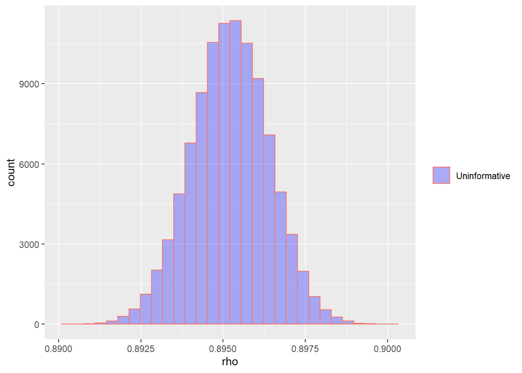

```r
library(MCMCpack)
set.seed(919)
S   <- 100000
p = 2

# https://www4.stat.ncsu.edu/~bjreich/ST740/covariance.html
# these values of nu and Psi put a uniform(0,1) prior on Sigma
nu = p+1
Psi= diag(p)
n = length(TMAX)

y = array(c(weather$temp_min, weather$temp_max), dim=c(n,2))
ybar = array(c(mean(y[,1]), mean(y[,2])), dim=c(1,2))

sum_mat = array(0, dim=c(p,p))

for(i in 1:n){
  sum_mat = sum_mat + t(y[i,] - ybar) %*% (y[i,] - ybar)
}



Sig <- array(0,c(S,p,p))
SigInv <- Sig

for(s in 1:S){
  #  Sample inverse gamma from wishart (with inverse params)
   SigInv[s,,] <- rwish(nu + n, solve(Psi + sum_mat))

   # invert to get back sigma
   Sig[s,,]    <- solve(SigInv[s,,])
}

rho = Sig[,1,2]/sqrt(Sig[,1,1] * Sig[,2,2])

rho_mean = mean(rho)
rho_sd = sd(rho)
rho_lower = rho_mean - qnorm(0.975) * rho_sd
rho_upper = rho_mean + qnorm(0.975) * rho_sd


ggplot(data.frame(rho)) +
  geom_histogram(aes(x=rho, color="Uninformative"), alpha=0.3, fill="blue") +
  labs(x = "rho") +
  theme(legend.title=element_blank())
```

```r
# paste0(round(rho_mean, digits=3), " | ", round(rho_sd, digits=3), " | (", round(rho_lower, digits=3), " , ", round(rho_upper, digits=3), ") |")
```

|  | Posterior Mean | Posterior SD | 95% credible set |
| --- | --- | --- | --- |
| uninformative prior $\rho$ | 0.895 | 0.001 | (0.892 , 0.897) |

Since the 95% credible set does not contain 0, there is statistically signification correlation between the variables.

**(d) Fit the model to the temperature data separately by month (including monthly $\overline{Y }$) and plot the posterior distribution of the correlation between $T_{MIN}$ and $T_{MAX}$ $(\rho)$ by month. Is there a statistically significant correlation between these variables? Are there statistically significant differences by month?**

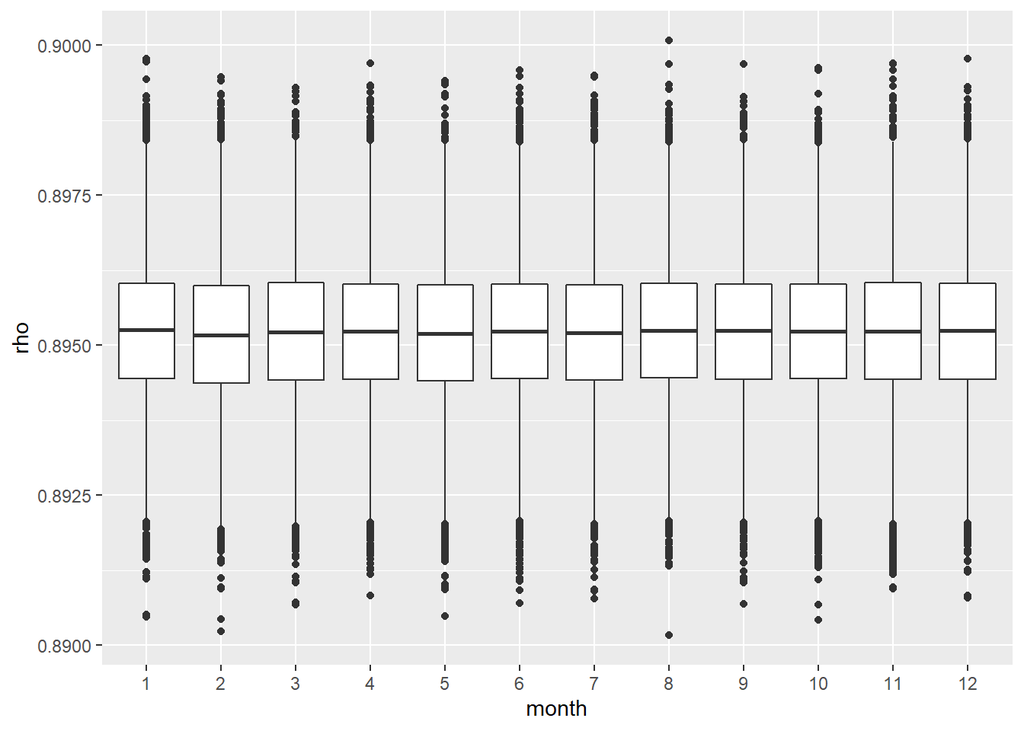

```r
set.seed(919)
S   <- 10000
p = 2

# https://www4.stat.ncsu.edu/~bjreich/ST740/covariance.html
# these values of nu and Psi put a uniform(0,1) prior on Sigma
nu = p+1
Psi= diag(p)
n = length(TMAX)
rho_df = data.frame()
rho$rho=0
rho$month=0

for(month in 1:12){

  weather_month = weather %>% filter(month == month)
  y = array(c(weather_month$temp_min, weather_month$temp_max), dim=c(n,2))
  ybar = array(c(mean(y[,1]), mean(y[,2])), dim=c(1,2))

  sum_mat = array(0, dim=c(p,p))

  for(i in 1:n){
    sum_mat = sum_mat + t(y[i,] - ybar) %*% (y[i,] - ybar)
  }



  Sig <- array(0,c(S,p,p))
  SigInv <- Sig

  for(s in 1:S){
    #  Sample inverse gamma from wishart (with inverse params)
     SigInv[s,,] <- rwish(nu + n, solve(Psi + sum_mat))

     # invert to get back sigma
     Sig[s,,]    <- solve(SigInv[s,,])
  }

  rho = Sig[,1,2]/sqrt(Sig[,1,1] * Sig[,2,2])
  temp_df = data.frame(rho=rho, month=rep(month, length(rho)))
  rho_df = rbind(rho_df,temp_df)

  rho_mean = mean(rho)
  rho_sd = sd(rho)
  rho_lower = rho_mean - qnorm(0.975) * rho_sd
  rho_upper = rho_mean + qnorm(0.975) * rho_sd

  # print(paste0("| month ", month , " | ",round(rho_mean, digits=7), " | ", round(rho_sd, digits=7), " | (", round(rho_lower, digits=7), " , ", round(rho_upper, digits=7), ") |"))
}

rho_df$month = as.factor(rho_df$month)
ggplot(rho_df, aes(x=month, y=rho)) +
 geom_boxplot()
```

Note that up to 3 significant digits, all of the posterior mean, standard deviations, and credible sets are the same for each month.

| $\rho$ | Posterior Mean | Posterior SD | 95% credible set |
| --- | --- | --- | --- |
| month 1 | 0.8952212 | 0.0011858 | (0.892897 , 0.8975453) |
| month 2 | 0.8952215 | 0.0011909 | (0.8928874 , 0.8975556) |
| month 3 | 0.8952159 | 0.0011936 | (0.8928765 , 0.8975552) |
| month 4 | 0.8952117 | 0.001183 | (0.8928931 , 0.8975304) |
| month 5 | 0.8952102 | 0.0011851 | (0.8928874 , 0.8975329) |
| month 6 | 0.8952032 | 0.0011935 | (0.892864 , 0.8975423) |
| month 7 | 0.8952212 | 0.0011699 | (0.8929282 , 0.8975141) |
| month 8 | 0.8952268 | 0.0011995 | (0.8928759 , 0.8975778) |
| month 9 | 0.8952331 | 0.0011971 | (0.8928869 , 0.8975794) |
| month 10 | 0.8952031 | 0.0011803 | (0.8928898 , 0.8975164) |
| month 11 | 0.8952115 | 0.0011852 | (0.8928885 , 0.8975345) |
| month 12 | 0.8952084 | 0.0011812 | (0.8928933 , 0.8975235) |